# Modelos de Regressão Multinível: Laboratório

Tiago Ferreira

**EXERCÍCIO 2**  
A base de dados “popular” foi retirada do livro *Multilevel Analysis Techniques and Applications* (Hox, 2010) e contem características de estudantes em diferentes turmas. A nossa variável de interesse neste exercício será o estatuto sociométrico (*popular*) dos alunos. Procuraremos explicar esta variável em função dos níveis individuais de extroversão (*extrav*), sexo (*sex*) e dos anos de experiência pedagógica do professor (“texp”). Alguns dos exercícios propostos de seguida foram retirados de um tutorial criado por Laurent Smeets e Rens van de Schoot e pode ser encontrado no seguinte [aqui](https://www.rensvandeschoot.com/tutorials/lme4/).

1. Importar para o R a base de dados (BD) do ficheiro spss (.sav) ou texto (.csv). Para importar do spss recorra à função foreign::read.spss.

```r
if(!require("foreign")) install.packages("foreign")  # instalar o pacote se necessário
DF_POPULAR <- read.spss("G:\\My Drive\\FPCEUP\\AtividadeDocente\\MultilevelReg\\MLReg_data\\popular.sav", to.data.frame = TRUE)

DF_POPULAR <-
  read.csv2(
    "G:\\My Drive\\FPCEUP\\AtividadeDocente\\MultilevelReg\\MLReg_data\\popular.csv",
    fileEncoding="UTF-8-BOM")
```

2. Verificar as dimensões da BD e visualizar alguns dos seus dados.

```r
dim(DF_POPULAR)
```

```
## [1] 2000    6
```

```r
head(DF_POPULAR)
```

```
##   pupil class extrav sex texp popular
## 1     1     1      5   1   24     6.3
## 2     2     1      7   0   24     4.9
## 3     3     1      4   1   24     5.3
## 4     4     1      3   1   24     4.7
## 5     5     1      5   1   24     6.0
## 6     6     1      4   0   24     4.7
```

3. Inspecionar a classe das variáveis e sumariar essas mesmas variáveis.

```r
str(DF_POPULAR)
```

```
## 'data.frame':    2000 obs. of  6 variables:
##  $ pupil  : int  1 2 3 4 5 6 7 8 9 10 ...
##  $ class  : int  1 1 1 1 1 1 1 1 1 1 ...
##  $ extrav : int  5 7 4 3 5 4 5 4 5 5 ...
##  $ sex    : int  1 0 1 1 1 0 0 0 0 0 ...
##  $ texp   : int  24 24 24 24 24 24 24 24 24 24 ...
##  $ popular: num  6.3 4.9 5.3 4.7 6 4.7 5.9 4.2 5.2 3.9 ...
```

```r
summary(DF_POPULAR)
```

```
##      pupil           class            extrav            sex
##  Min.   : 1.00   Min.   :  1.00   Min.   : 1.000   Min.   :0.0000
##  1st Qu.: 6.00   1st Qu.: 25.00   1st Qu.: 4.000   1st Qu.:0.0000
##  Median :11.00   Median : 51.00   Median : 5.000   Median :1.0000
##  Mean   :10.65   Mean   : 50.37   Mean   : 5.215   Mean   :0.5055
##  3rd Qu.:16.00   3rd Qu.: 76.00   3rd Qu.: 6.000   3rd Qu.:1.0000
##  Max.   :26.00   Max.   :100.00   Max.   :10.000   Max.   :1.0000
##       texp          popular
##  Min.   : 2.00   Min.   :0.000
##  1st Qu.: 8.00   1st Qu.:4.100
##  Median :15.00   Median :5.100
##  Mean   :14.26   Mean   :5.076
##  3rd Qu.:20.00   3rd Qu.:6.000
##  Max.   :25.00   Max.   :9.500
```

4. Utilizar a função plot() para visualizar a relação entre as variáveis extroversão (*extrav*) e popularidade (*popular*).

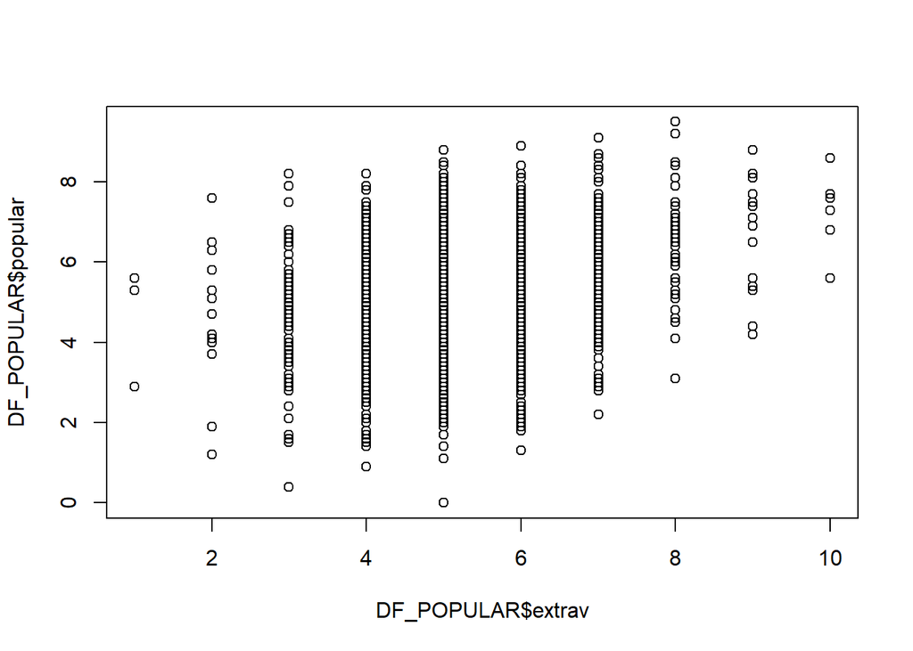

```r
plot(DF_POPULAR$extrav, DF_POPULAR$popular)
```

5. Testar um modelo de regressão simples, explicando popularidade (*popular*) em função de extroversão (*extrav*). O que é que os resultados sugerem?

```r
model1 <- lm(popular ~ extrav, data = DF_POPULAR)
summary(model1)
```

```
##
## Call:
## lm(formula = popular ~ extrav, data = DF_POPULAR)
##
## Residuals:
##     Min      1Q  Median      3Q     Max
## -5.0021 -0.9021  0.0062  0.8896  3.8896
##
## Coefficients:
##             Estimate Std. Error t value Pr(>|t|)
## (Intercept)  3.27284    0.12474   26.24   <2e-16 ***
## extrav       0.34585    0.02325   14.88   <2e-16 ***
## ---
## Signif. codes:  0 '***' 0.001 '**' 0.01 '*' 0.05 '.' 0.1 ' ' 1
##
## Residual standard error: 1.312 on 1998 degrees of freedom
## Multiple R-squared:  0.09973,    Adjusted R-squared:  0.09927
## F-statistic: 221.3 on 1 and 1998 DF,  p-value: < 2.2e-16
```

6. Verificar se existe um efeito da turma sobre os scores de popularidade dos alunos. Para o efeito, calcular o ICC. Em que medida considera necessário adotar uma abordagem de análise multi-nível?

```r
if(!require("lme4")) install.packages("lme4") # instalar o pacote se necessário
null <- lmer(popular  ~ 1 # define “popular” em função do intercept (fixed effect)
             + (1|class), # e que cada turma tem o seu intercept (random effect)
             data=DF_POPULAR)
summary(null)
```

```
## Linear mixed model fit by REML ['lmerMod']
## Formula: popular ~ 1 + (1 | class)
##    Data: DF_POPULAR
##
## REML criterion at convergence: 6330.5
##
## Scaled residuals:
##     Min      1Q  Median      3Q     Max
## -3.5655 -0.6975  0.0020  0.6758  3.3175
##
## Random effects:
##  Groups   Name        Variance Std.Dev.
##  class    (Intercept) 0.7021   0.8379
##  Residual             1.2218   1.1053
## Number of obs: 2000, groups:  class, 100
##
## Fixed effects:
##             Estimate Std. Error t value
## (Intercept)  5.07786    0.08739    58.1
```

```r
ICC <- 0.7021/(0.7021+1.2218)
ICC
```

```
## [1] 0.3649358
```

```r
ICC_user <- function(nome.modelo) {
  vc <- VarCorr(nome.modelo)
  vc <- print(vc, comp=c("Variance", "Std.Dev"))
  vc <- as.data.frame(vc)[,c("grp", "vcov")]
  ICC <- vc[1,2]/sum(vc[,2])
  return(c(ICC = ICC))
}
ICC_user(null)
```

```
##  Groups   Name        Variance Std.Dev.
##  class    (Intercept) 0.7021   0.83792
##  Residual             1.2218   1.10535
```

```
##       ICC
## 0.3649386
```

```r
if(!require("performance")) install.packages("performance")  # instalar o pacote se necessário
icc(null)
```

```
## # Intraclass Correlation Coefficient
##
##     Adjusted ICC: 0.365
##   Unadjusted ICC: 0.365
```

7. Examinar os efeitos fixos de sexo (*sex*; 0=rapaz, 1=rapariga) e experiência do professor (*texp*) sobre popularidade, controlado o impacto da turma no valor médios de popularidade dos alunos. Se considerar útil, poderá centrar as variáveis preditivas. Reportar os valores de R2 e *p* utilizando o ajustamento de Satterthwaite.

```r
DF_POPULAR$texp.c <- scale(DF_POPULAR$texp, scale = FALSE)[,]
head(DF_POPULAR)
```

```
##   pupil class extrav sex texp popular texp.c
## 1     1     1      5   1   24     6.3  9.737
## 2     2     1      7   0   24     4.9  9.737
## 3     3     1      4   1   24     5.3  9.737
## 4     4     1      3   1   24     4.7  9.737
## 5     5     1      5   1   24     6.0  9.737
## 6     6     1      4   0   24     4.7  9.737
```

```r
model2 <- lmer(popular ~ sex + texp.c + (1 | class), data=DF_POPULAR)
summary(model2)
```

```
## Linear mixed model fit by REML ['lmerMod']
## Formula: popular ~ sex + texp.c + (1 | class)
##    Data: DF_POPULAR
##
## REML criterion at convergence: 5544
##
## Scaled residuals:
##     Min      1Q  Median      3Q     Max
## -3.6546 -0.6520  0.0012  0.6721  3.1327
##
## Random effects:
##  Groups   Name        Variance Std.Dev.
##  class    (Intercept) 0.3606   0.6005
##  Residual             0.8307   0.9114
## Number of obs: 2000, groups:  class, 100
##
## Fixed effects:
##             Estimate Std. Error t value
## (Intercept) 4.392424   0.067230  65.334
## sex         1.350637   0.043949  30.732
## texp.c      0.054061   0.009655   5.599
##
## Correlation of Fixed Effects:
##        (Intr) sex
## sex    -0.331
## texp.c  0.004 -0.026
```

```r
if(!require("MuMIn")) install.packages("MuMIn")  # instalar o pacote se necessário
?r.squaredGLMM
```

```
## starting httpd help server ...
```

```
##  done
```

```r
r.squaredGLMM(model2)
```

```
##            R2m       R2c
## [1,] 0.3410013 0.5404718
```

```r
if(!require("lmerTest")) install.packages("lmerTest")  # instalar o pacote se necessário
model2 <- lmer(popular ~ sex + texp.c + (1 | class), data=DF_POPULAR)
summary(model2, ddf = "Satterthwaite")
```

```
## Linear mixed model fit by REML. t-tests use Satterthwaite's method [
## lmerModLmerTest]
## Formula: popular ~ sex + texp.c + (1 | class)
##    Data: DF_POPULAR
##
## REML criterion at convergence: 5544
##
## Scaled residuals:
##     Min      1Q  Median      3Q     Max
## -3.6546 -0.6520  0.0012  0.6721  3.1327
##
## Random effects:
##  Groups   Name        Variance Std.Dev.
##  class    (Intercept) 0.3606   0.6005
##  Residual             0.8307   0.9114
## Number of obs: 2000, groups:  class, 100
##
## Fixed effects:
##              Estimate Std. Error        df t value Pr(>|t|)
## (Intercept) 4.392e+00  6.723e-02 1.223e+02  65.334  < 2e-16 ***
## sex         1.351e+00  4.395e-02 1.957e+03  30.732  < 2e-16 ***
## texp.c      5.406e-02  9.655e-03 9.774e+01   5.599 1.98e-07 ***
## ---
## Signif. codes:  0 '***' 0.001 '**' 0.01 '*' 0.05 '.' 0.1 ' ' 1
##
## Correlation of Fixed Effects:
##        (Intr) sex
## sex    -0.331
## texp.c  0.004 -0.026
```

8. Adicionar ao modelo anterior o efeito fixo de extroversão no nível 1 (*extrav*). Compare este modelo com o modelo anterior e interprete os resultados.

```r
DF_POPULAR$extrav.c <- scale(DF_POPULAR$extrav, scale = FALSE)[,]
model3 <- lmer(popular ~ sex + texp.c + extrav.c + (1 | class), data=DF_POPULAR)
summary(model3)
```

```
## Linear mixed model fit by REML. t-tests use Satterthwaite's method [
## lmerModLmerTest]
## Formula: popular ~ sex + texp.c + extrav.c + (1 | class)
##    Data: DF_POPULAR
##
## REML criterion at convergence: 4885
##
## Scaled residuals:
##     Min      1Q  Median      3Q     Max
## -3.1745 -0.6491 -0.0075  0.6705  3.0078
##
## Random effects:
##  Groups   Name        Variance Std.Dev.
##  class    (Intercept) 0.2954   0.5435
##  Residual             0.5920   0.7694
## Number of obs: 2000, groups:  class, 100
##
## Fixed effects:
##              Estimate Std. Error        df t value Pr(>|t|)
## (Intercept) 4.441e+00  6.007e-02 1.196e+02   73.92   <2e-16 ***
## sex         1.254e+00  3.729e-02 1.948e+03   33.62   <2e-16 ***
## texp.c      8.841e-02  8.764e-03 1.016e+02   10.09   <2e-16 ***
## extrav.c    4.544e-01  1.616e-02 1.955e+03   28.11   <2e-16 ***
## ---
## Signif. codes:  0 '***' 0.001 '**' 0.01 '*' 0.05 '.' 0.1 ' ' 1
##
## Correlation of Fixed Effects:
##          (Intr) sex    texp.c
## sex      -0.314
## texp.c    0.007 -0.036
## extrav.c  0.028 -0.090  0.139
```

```r
r.squaredGLMM(model3)
```

```
##            R2m       R2c
## [1,] 0.5084324 0.6720618
```

```r
anova(model2, model3)
```

```
## refitting model(s) with ML (instead of REML)
```

```
## Data: DF_POPULAR
## Models:
## model2: popular ~ sex + texp.c + (1 | class)
## model3: popular ~ sex + texp.c + extrav.c + (1 | class)
##        npar    AIC    BIC  logLik deviance  Chisq Df Pr(>Chisq)
## model2    5 5538.5 5566.5 -2764.2   5528.5
## model3    6 4874.3 4907.9 -2431.2   4862.3 666.17  1  < 2.2e-16 ***
## ---
## Signif. codes:  0 '***' 0.001 '**' 0.01 '*' 0.05 '.' 0.1 ' ' 1
```

```r
if(!require("effectsize")) install.packages("effectsize")  # instalar o pacote se necessário
standardize_parameters(model3, method = "refit")
```

```
## # Standardization method: refit
##
## Parameter   | Std. Coef. |        95% CI
## ----------------------------------------
## (Intercept) |  -1.50e-03 | [-0.08, 0.08]
## sex         |       0.45 | [ 0.43, 0.48]
## texp c      |       0.42 | [ 0.34, 0.50]
## extrav c    |       0.41 | [ 0.39, 0.44]
```

9. Incluir os random effects das variáveis de nível 1. O que sugerem estes novos resultados?

```r
model4 <- lmer(popular ~ 1 + sex + extrav.c + texp.c + (1 + sex + extrav.c | class), REML=FALSE, data = DF_POPULAR)
summary(model4)
```

```
## Linear mixed model fit by maximum likelihood . t-tests use Satterthwaite's
##   method [lmerModLmerTest]
## Formula: popular ~ 1 + sex + extrav.c + texp.c + (1 + sex + extrav.c |
##     class)
##    Data: DF_POPULAR
##
##      AIC      BIC   logLik deviance df.resid
##   4833.3   4894.9  -2405.6   4811.3     1989
##
## Scaled residuals:
##     Min      1Q  Median      3Q     Max
## -3.1686 -0.6550 -0.0227  0.6728  2.9571
##
## Random effects:
##  Groups   Name        Variance Std.Dev. Corr
##  class    (Intercept) 0.304280 0.55162
##           sex         0.002389 0.04888  -0.99
##           extrav.c    0.034115 0.18470  -0.08 -0.09
##  Residual             0.551144 0.74239
## Number of obs: 2000, groups:  class, 100
##
## Fixed effects:
##              Estimate Std. Error        df t value Pr(>|t|)
## (Intercept) 4.397e+00  6.102e-02 9.309e+01   72.06   <2e-16 ***
## sex         1.251e+00  3.692e-02 9.930e+02   33.88   <2e-16 ***
## extrav.c    4.529e-01  2.451e-02 9.715e+01   18.48   <2e-16 ***
## texp.c      8.942e-02  8.533e-03 1.034e+02   10.48   <2e-16 ***
## ---
## Signif. codes:  0 '***' 0.001 '**' 0.01 '*' 0.05 '.' 0.1 ' ' 1
##
## Correlation of Fixed Effects:
##          (Intr) sex    extrv.
## sex      -0.417
## extrav.c -0.036 -0.066
## texp.c   -0.010 -0.040  0.090
```

```r
r.squaredGLMM(model4)
```

```
##           R2m       R2c
## [1,] 0.509856 0.6944199
```

```r
anova(model3, model4)
```

```
## refitting model(s) with ML (instead of REML)
```

```
## Data: DF_POPULAR
## Models:
## model3: popular ~ sex + texp.c + extrav.c + (1 | class)
## model4: popular ~ 1 + sex + extrav.c + texp.c + (1 + sex + extrav.c | class)
##        npar    AIC    BIC  logLik deviance  Chisq Df Pr(>Chisq)
## model3    6 4874.3 4907.9 -2431.2   4862.3
## model4   11 4833.3 4894.9 -2405.6   4811.3 51.009  5  8.611e-10 ***
## ---
## Signif. codes:  0 '***' 0.001 '**' 0.01 '*' 0.05 '.' 0.1 ' ' 1
```

10. Recorrer à função lmerTest::ranova() para perceber se faz sentido conduzir alguma re-especificação do modelo anterior. Se sim, testar o novo modelo e comparar com o modelo anterior. O que se pode concluir?

```r
ranova(model4)
```

```
## boundary (singular) fit: see help('isSingular')
```

```
## ANOVA-like table for random-effects: Single term deletions
##
## Model:
## popular ~ sex + extrav.c + texp.c + (1 + sex + extrav.c | class)
##                                          npar  logLik    AIC    LRT Df
## <none>                                     11 -2405.6 4833.3
## sex in (1 + sex + extrav.c | class)         8 -2406.4 4828.8  1.521  3
## extrav.c in (1 + sex + extrav.c | class)    8 -2430.5 4877.0 49.744  3
##                                          Pr(>Chisq)
## <none>
## sex in (1 + sex + extrav.c | class)          0.6775
## extrav.c in (1 + sex + extrav.c | class)  9.057e-11 ***
## ---
## Signif. codes:  0 '***' 0.001 '**' 0.01 '*' 0.05 '.' 0.1 ' ' 1
```

```r
model5 <- lmer(popular ~ 1 + sex + extrav + texp + (1 + extrav | class), data = DF_POPULAR)
summary(model5)
```

```
## Linear mixed model fit by REML. t-tests use Satterthwaite's method [
## lmerModLmerTest]
## Formula: popular ~ 1 + sex + extrav + texp + (1 + extrav | class)
##    Data: DF_POPULAR
##
## REML criterion at convergence: 4834.8
##
## Scaled residuals:
##     Min      1Q  Median      3Q     Max
## -3.1768 -0.6475 -0.0235  0.6648  2.9684
##
## Random effects:
##  Groups   Name        Variance Std.Dev. Corr
##  class    (Intercept) 1.30299  1.1415
##           extrav      0.03455  0.1859   -0.89
##  Residual             0.55209  0.7430
## Number of obs: 2000, groups:  class, 100
##
## Fixed effects:
##              Estimate Std. Error        df t value Pr(>|t|)
## (Intercept) 7.361e-01  1.966e-01 1.821e+02   3.745 0.000242 ***
## sex         1.252e+00  3.657e-02 1.913e+03  34.240  < 2e-16 ***
## extrav      4.526e-01  2.461e-02 9.754e+01  18.389  < 2e-16 ***
## texp        9.098e-02  8.685e-03 1.017e+02  10.475  < 2e-16 ***
## ---
## Signif. codes:  0 '***' 0.001 '**' 0.01 '*' 0.05 '.' 0.1 ' ' 1
##
## Correlation of Fixed Effects:
##        (Intr) sex    extrav
## sex    -0.031
## extrav -0.717 -0.057
## texp   -0.688 -0.039  0.086
```

```r
r.squaredGLMM(model5)
```

```
##            R2m       R2c
## [1,] 0.5105624 0.6964809
```

```r
anova(model4, model5)
```

```
## refitting model(s) with ML (instead of REML)
```

```
## Data: DF_POPULAR
## Models:
## model5: popular ~ 1 + sex + extrav + texp + (1 + extrav | class)
## model4: popular ~ 1 + sex + extrav.c + texp.c + (1 + sex + extrav.c | class)
##        npar    AIC    BIC  logLik deviance  Chisq Df Pr(>Chisq)
## model5    8 4828.8 4873.6 -2406.4   4812.8
## model4   11 4833.3 4894.9 -2405.6   4811.3 1.5208  3     0.6775
```